# assignment01

## Part II: Static Mapping

- `Data Preparation`:
  - The restaurant data from Yelp API is collected and stored in a DataFrame called 'resturants_df'
  - The latitude and longitude coordinates are extracted from the 'coordinates' column and stored in separate columns.
  - The 'alias' and 'title' columns are created to extract the category alias and title from the 'categories' column.
  - The DataFrame is converted into a GeoDataFrame 'gdf' to enable plotting geographic data.

```python
resturants_df = pd.DataFrame(combined_results) #  converting jason response into panda DataFrame

resturants_df[['latitude', 'longitude']] = resturants_df['coordinates'].apply(lambda x: pd.Series([x['latitude'], x['longitude']]))
resturants_df[['alias', 'title']] = resturants_df['categories'].apply(lambda x: pd.Series([x[0]['alias'], x[0]['title']]))

# Convert DataFrame to GeoDataFrame to plot cordinates in static map
gdf = gpd.GeoDataFrame(resturants_df, geometry=gpd.points_from_xy(resturants_df.longitude, resturants_df.latitude))
```

- `Categorization`:
  - A function 'map_alias' is defined to map restaurant aliases to broader categories such as 'coffee', 'sweets_n_desserts', 'wine_bars', and 'restaurants'
  - This function is applied to create a new column 'new_alias' in both the 'resturants_df' and 'gdf' DataFrames, categorizing the restaurants.

```python
# Define a function to map aliases to new aliases
def map_alias(alias):
    if alias in ['coffee', 'cafes', 'coffeeroasteries','tea','cafeteria']:
        return 'coffee'
    elif alias in ['bakeries', 'icecream', 'cakeshop', 'donuts','chocolate','desserts','pancakes','waffles']:
        return 'sweets_n_desserts'
    elif alias in ['bars', 'wine_bars', 'whiskeybars']:
        return 'wine_bars'
    elif alias in ['breakfast_brunch', 'restaurants', 'diners']:
        return 'restaurants'
    else:
        return alias

# Apply the function to create the new column
resturants_df['new_alias'] = resturants_df['alias'].apply(map_alias)
# Apply the function to create the new column
gdf['new_alias'] = gdf['alias'].apply(map_alias) #adding this new alias in geo data frame to categories the plots
```

```python
resturants_df.to_csv('../data/London_resturants_data.csv', index=False) #storing data in csv file in case api key for yelp stops working
```

- `Plotting`:
  - CRS of the GeoDataFrame 'gdf' is set to WGS84 (EPSG:4326) initially and data is projected to the British Grid - London (EPSG:27700) to match the boundary shapefile. taken from : https://epsg.io/?q=great+britain
  - This function is applied to create a new column 'new_alias' in both the 'resturants_df' and 'gdf' DataFrames, categorizing the restaurants.
  - Colors and marker styles are defined for each restaurant category
  - Restaurants are plotted on the map using different colors and marker styles based on their categories.
  - The boundary layer is plotted with black edges to outline the boroughs.
  - A basemap from CartoDB.Positron is added to the map with contextily. taken from : https://xyzservices.readthedocs.io/en/stable/introduction.html

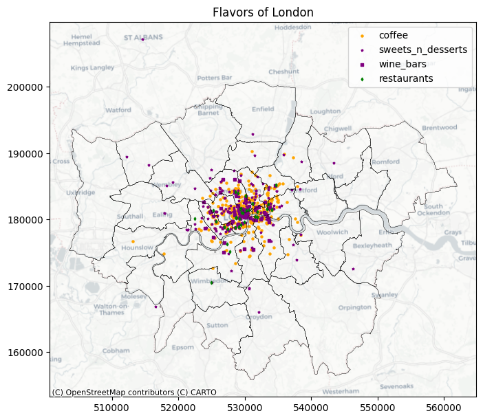

```python
# Setting the Coordinate Reference System (CRS) to WGS84 (EPSG:4326)
gdf.set_crs(epsg=4326, inplace=True)
# project to British Grid -London
gdf.to_crs(epsg= 27700, inplace = True)
boundary_gdf = gpd.read_file('../data/ESRI/London_Borough_Excluding_MHW.shp')
boundary_gdf = boundary_gdf.to_crs(epsg=27700)

# Define colors and marker styles for each category
category_styles = {
    'coffee': ('orange', 'o'),  # Circle marker for coffee
    'sweets_n_desserts': ('purple', '*'),  # Star marker for dessert
    'wine_bars': ('purple', 's'),  # Square marker for wine bars
    'restaurants': ('green', 'd')  # Diamond marker for restaurants
}

# Plotting restaurants on a map with different colors and marker styles based on category
fig, ax = plt.subplots(1, 1, figsize=(8, 10))

# Iterate over each category and plot it with the corresponding color and marker style
for category, (color, marker) in category_styles.items():
    category_gdf = gdf[gdf['new_alias'] == category]
    category_gdf.plot(ax=ax, color=color, markersize=5, marker=marker, label=category)

# Plot the boundary layer
    boundary_gdf.plot(ax=ax, color='none', edgecolor='black', linewidth=0.1)

# Add basemap
ctx.add_basemap(ax, crs=boundary_gdf.crs, source=ctx.providers.CartoDB.Positron)

# Set title and legend
ax.set_title('Flavors of London')
ax.legend()

plt.show()
```

## Part III: Choropleth Mapping

- `Data Merging`:
  - Creating a choropleth map displaying restaurant ratings across London regions
  - The CRS of the 'restaurant_geo' GeoDataFrame is reprojected to match the CRS of the boundary shapefile of London regions ('boundary_gdf').
  - A spatial join is performed between the London regions (from 'boundary_gdf') and the restaurants (from 'restaurant_geo') based on their spatial relationship..
  - The join operation is based on containment, meaning each London region contains some restaurants within its boundaries

```python
# Convert restaurant data to a GeoDataFrame and set CRS
restaurant_geo = gpd.GeoDataFrame(resturants_df, geometry=gpd.points_from_xy(resturants_df.longitude, resturants_df.latitude),crs='EPSG:4326')

# Reproject restaurant GeoDataFrame to match CRS of London regions
restaurant_geo = restaurant_geo.to_crs(boundary_gdf.crs)

# Perform spatial join based on nearest distance
merged_data = gpd.sjoin(boundary_gdf, restaurant_geo, how='left', op='contains')
```

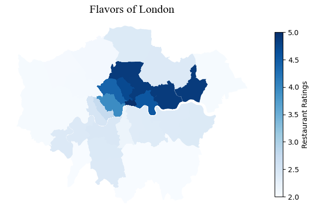

```python
# Create a figure and axis
fig, ax = plt.subplots(1, 1, figsize=(8, 6))

merged_data.plot(ax=ax, linewidth=0.3, cmap='Blues', legend=True) # Plot the merged data as a choropleth map
ax.set_axis_off()

# Set title
title_parameters = {'fontsize': '16', 'fontname': 'Times New Roman'}
ax.set_title("Flavors of London", **title_parameters)

# Add a color scale (colorbar)
# Create a colormap and normalize the colors
cmap = plt.cm.get_cmap('Blues')
norm = mcolors.Normalize(vmin=merged_data['rating'].min(), vmax=merged_data['rating'].max())

# Create the colorbar
sm = plt.cm.ScalarMappable(cmap=cmap, norm=norm)
sm.set_array([])  # Set an empty array since we don't need the colorbar to represent any specific values
cbar = plt.colorbar(sm, ax=ax, shrink=0.7)
cbar.set_label('Restaurant Ratings', rotation=90)  # Set the label for the colorbar

# Show the plot
plt.show()
```

## Part IV: Interactive Mapping

- `Description`:
  - This interactive map showcases the vibrant culinary landscape of London, overlaying restaurant locations on a detailed geographic map. The map is centered around London with a zoom level set to capture a comprehensive view. Utilizing GeoJSON data, London's administrative boundaries are outlined in blue, with a yellow fill to distinguish them from the surrounding area.
  - Markers are clustered together for improved readability, making it easy for users to explore numerous restaurant locations within close proximity. Each marker represents a unique dining establishment and provides essential information such as the restaurant name, rating, address, and price range. Additionally, a thumbnail image of the restaurant is displayed in the marker's popup, offering users a visual preview of the dining experience.
  - Users can interact with the map by clicking on individual markers to view detailed information about each restaurant. The popup window dynamically adjusts to accommodate the restaurant's name, rating, address, price range, and an optional image. Moreover, a tooltip displays the restaurant's name and rating upon hovering over the marker, allowing for quick insights into nearby dining options.

```python
# Load GeoJSON file
geojson_file = "../data/london.geojson"
```

```python
import folium
from folium import plugins

# Create map centered at the specified location
map_center = folium.Map(location=[51.51283552118349,-0.135955810546875], zoom_start=10) # selected london latitude and longitude and zoom level 10

# Add OpenStreetMap tile layer
folium.TileLayer('openstreetmap').add_to(map_center)

# Add another tile layer (for example, Stamen Terrain) with attribution
folium.TileLayer('stamenterrain', attr='Stamen Terrain').add_to(map_center)

# Customize the appearance of the GeoJSON overlay
style_function = lambda x: {'color': 'blue', 'fillColor': 'yellow', 'weight': 2, 'opacity': 0.6}

# Add GeoJSON overlay to the map
folium.GeoJson(geojson_file, style_function=style_function).add_to(map_center)

# Create a marker cluster
marker_cluster = plugins.MarkerCluster().add_to(map_center)

# Add markers for each restaurant to the marker cluster
for business in combined_results:
    name = business['name']
    lat = business['coordinates']['latitude']
    lon = business['coordinates']['longitude']
    rating = business['rating']
    address = ', '.join(business['location']['display_address'])
    image_url = business.get('image_url')
    web_url = business.get('url')
    price = business.get('price')
    category = gdf['new_alias']
    popup_text = f"<b>{name}</b><br>Rating: {rating}<br>Address: {address}<br>Price: {price}<br> <img src='{image_url}' width='200px'><br> <h5>Check out more <a href='{web_url}' target='_blank'>here</a></h5>"
    tooltip_text = f"{name} - Rating: {rating}"

    # Add marker to the marker cluster
    folium.Marker([lat, lon], popup=folium.Popup(popup_text, max_width=300), tooltip=tooltip_text).add_to(marker_cluster)

# Add layer control
folium.LayerControl().add_to(map_center)

# Display the map
map_center
```

Make this Notebook Trusted to load map: File -> Trust Notebook

[interactive chart not shown]

### Conclusion

- "Flavors of London - Mapping Restaurants and Cafés" is a comprehensive guide that enables users to explore London's diverse culinary scene. Leveraging the Yelp API, the map provides detailed insights into various dining options, including coffee shops, dessert spots, and wine bars, empowering users to make informed choices. By efficiently fetching data and categorizing establishments, the map enhances user experience, simplifying navigation through London's bustling food landscape. Through the integration of static and choropleth mapping techniques, users can visualize restaurant distributions and ratings across the city's regions using interactive map. Ultimately, "Flavors of London" offers an immersive journey through the city's culinary delights, serving as a trusted companion for culinary exploration and discovery.

### References

- For an basics of static map, choloropeth map and interactive map ["Web Mapping and Geovisualisation"](https://gdsl-ul.github.io/wma/)
- to learn in detail about folium and Easy practical guides to get things done with python [Taming Python](https://nagasudhir.blogspot.com/2021/07/).
- to understand the detailed Restful web servises API and endpoints and all about backend [(yelp developer portal)](https://docs.developer.yelp.com/docs/getting-started)